# SoccerMon · Load, Wellness & Injury Monitor

Training sessions logged

16,265

Wellness reports

16,992

Wellness compliance

66.6%

Injury episodes

29

Weekly squad load by team

[interactive chart not shown]

Wellness compliance by month

[interactive chart not shown]

ACWR above 1.5

3

ACWR below 0.8

14

Low wellness (below -0.5)

5

Speak to first

4

Squad status, week ending 15/09/2021

| Player | Team | Weekly load | ACWR | Monotony | Wellness (7d) | Status |
| --- | --- | --- | --- | --- | --- | --- |
| B-08e3 | Team B | 2070 | 3.58 | 0.77 | -0.08 | Monitor |
| A-2d44 | Team A | 1515 | 2.66 | 1.3 | -0.01 | Monitor |
| B-29c5 | Team B | 830 | 1.75 | 0.62 | -0.61 | Speak to first |
| A-560c | Team A | 2650 | 1.38 | 1.74 | 0.09 | OK |
| A-c4cc | Team A | 2540 | 1.37 | 1.08 |  | OK |
| B-4d54 | Team B | 1920 | 1.25 | 1.3 | 0.06 | OK |
| A-3e5f | Team A | 2590 | 1.24 | 1.18 | 0.58 | OK |
| B-e432 | Team B | 2340 | 1.23 | 1.08 | -0.16 | OK |
| A-5cd7 | Team A | 4140 | 1.21 | 1.77 | -0.2 | OK |
| A-bcc0 | Team A | 3400 | 1.17 | 1.73 | -0.28 | OK |

[output cut: 32 more lines]

Load vs wellness (shaded = outside the safe range)

[interactive chart not shown]

Fatigue in the 28 days before injury (95% confidence band)

[interactive chart not shown]

Most-reported body areas

[interactive chart not shown]

Injury rate by previous-day ACWR (exact 95% CIs)

[interactive chart not shown]

What this page shows

- **No early warning from wellness:** fatigue in the final week before injury was no worse than in the three weeks before.
- **Knees dominate** reports, and almost all major ones.
- **High ACWR:** injuries were **2.4 times** as common above 1.5 (95% CI 0.70 to 7.15), but the interval includes 1. Based on 20 of 29 injuries.

**Load → next-day fatigue**

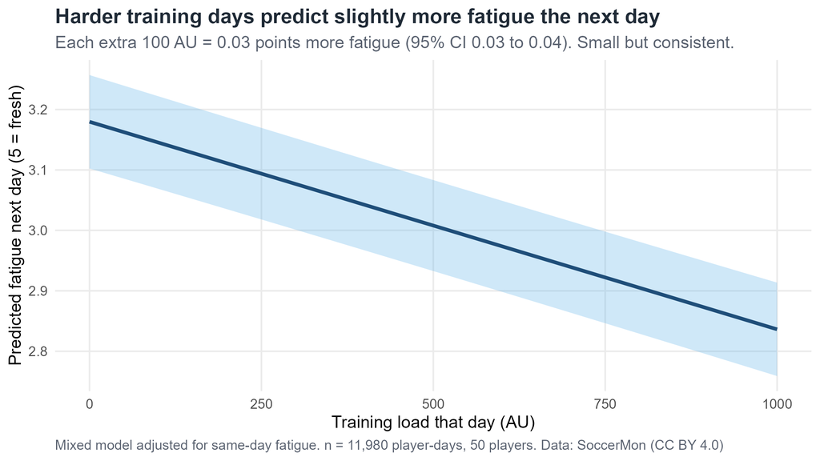

**Fatigue by load band**

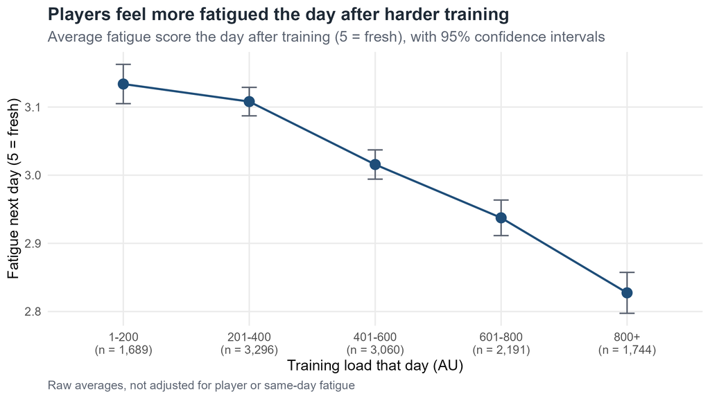

**Before injury**

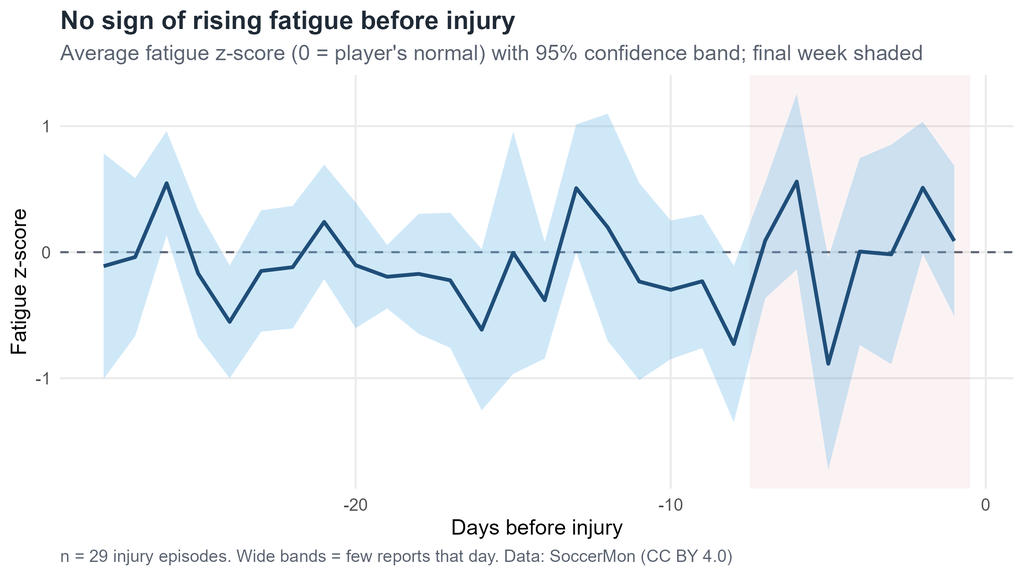

**ACWR and injury**

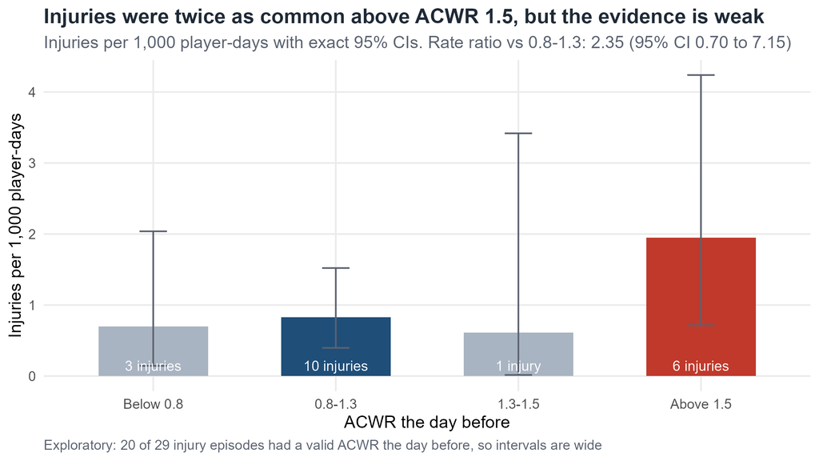

Key findings

**1. Load affects how players feel, but each session’s effect is small.** Each extra 100 AU predicted 0.034 points more fatigue the next day (95% CI 0.031 to 0.038) and 0.039 more soreness, consistent across both teams: about 0.1 points on a 1–5 scale for 600 vs 300 AU.

**2. Wellness gave no warning before injury.** Final-week fatigue was +0.23 SD versus days 8–28 (95% CI -0.03 to 0.49, p = 0.09).

**3. High ACWR may matter, but the sample is small.** Rate ratio 2.35 above 1.5 (95% CI 0.70 to 7.15).

**Data and methods:** SoccerMon (Midoglu et al., CC BY 4.0), 50 elite female players, 2020–21. Mixed models (lme4), paired t-tests and exact Poisson rate ratios. Built in R and Quarto by Will Page.